# About the seminar

**Abstract** The Slurm job-scheduler (currently used by USC) provides a flexible infrastructure for all your computing needs. From submitting a single-core-long-running-job to complex multi-node-tasks, Slurm covers all scientists’ needs in terms of computational resources management. The R programming language, although not HPC-ready, has multiple community-based solutions to integrate your computational pipeline with HPC settings, including Slurm. In this workshop, we will illustrate how to use R with USC’s HPC cluster, covering from the very basics, like submitting a simple R script, to the more complex-powerful settings, like using multinode socket clusters using dozens or hundreds of cores in the same R session. The workshop will be led by USC’s Division of Biostatistics at the Keck School of Medicine.

**Speaker** [George G. Vega Yon](https://ggvy.cl)

The webstite can be viewed [here](https://uscbiostats.github.io/slurmr-workshop)

# Featured Happy Scientist: Lynn Conway

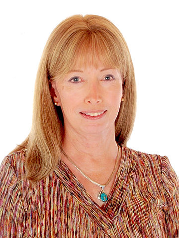

Lynn Conway July 2006. Source: [Wiki](https://en.wikipedia.org/wiki/File:Lynn_Conway_July_2006.jpg)

> Lynn Ann Conway (born January 2, 1938) is an American computer scientist, electrical engineer, inventor, and transgender activist. Conway is notable for a number of pioneering achievements. She worked at IBM in the 1960s and is credited with the invention of **generalized dynamic instruction handling**, a key advance used in **out-of-order execution**, used by most modern computer processors to improve performance. – ([Wiki](https://en.wikipedia.org/wiki/Lynn_Conway))